# MDA2025-U11-Losungen

```python
import numpy as np
import matplotlib.pyplot as plt
import matplotlib.cm as cm

import warnings
warnings.filterwarnings(action='ignore')
```

## Kurven im Raum

1. Der Ortsvektor einer räumlichen Kurve ist

$$ \vec{\mathbf{r}}(t) = \left[\begin{array}{c} 2 \cos(5t) \\ 2 \sin(5t) \\ 10t \end{array}\right] . $$

Bestimmen Sie am Punkt $t = \frac{\pi}{4}$:

- den Tangenteneinheitsvektor,
- den Normaleneinheitsvektor,
- und die Krümmung der Kurve.
2. Berechnen Sie die Bogenlänge entlang der Kurve

$$ \vec{\mathbf{r}}(t) = t\vec{\mathbf{e}}_x + t^2\vec{\mathbf{e}}_y $$

im Interval $0 \le t \le T$ mit $T > 0$.

3. Beschreiben Sie folgende Kurven durch parameterabhängige Ortsvektoren:
- die Parabel $y=x^2$ für $x \ge 0$,
- einen Längenkreis auf der Oberfläche einer Kugel,
- einen Breitenkreis auf der Oberfläche einer Kugel.

#### Lösung

*1)*

- Tangenteneinheitsvektor: $\vec{\mathbf{T}} = \dfrac{\dot{\vec{\mathbf{r}}}}{\|\dot{\vec{\mathbf{r}}}\|}$, $\dot{\vec{\mathbf{r}}} = \left[\begin{array}{c} -10 \sin(5t) \\ 10 \cos(5t) \\ 10 \end{array}\right], \; \dot{\vec{\mathbf{r}}}\left(\frac{\pi}{4}\right) = \left[\begin{array}{c} 5 \sqrt{2} \\ -5 \sqrt{2} \\ 10 \end{array}\right], \; \|\dot{\vec{\mathbf{r}}}\left(\frac{\pi}{4}\right)\| = 10\sqrt{2}, \; \vec{\mathbf{T}} = \left[\dfrac{1}{2}, -\dfrac{1}{2}, \dfrac{\sqrt{2}}{2}\right]^\mathrm{T}$
- allgemeiner Tangenteneinheitsvektor: $\vec{\mathbf{T}} = \dfrac{\sqrt{2}}{2}\left[-\sin(5t), \cos(5t), 1\right]^\mathrm{T}$
- Normaleneinheitsvektor: $\vec{\mathbf{N}} = \dfrac{\dot{\vec{\mathbf{T}}}}{\|\dot{\vec{\mathbf{T}}}\|}$, $\dot{\vec{\mathbf{T}}} = \dfrac{\sqrt{2}}{2}\left[-5\cos(5t), -5\sin(5t), 0\right]^\mathrm{T}, \; \dot{\vec{\mathbf{T}}}\left(\frac{\pi}{4}\right) = \dfrac{5}{2}\left[1, 1, 0\right]^\mathrm{T}, \; \|\dot{\vec{\mathbf{T}}}\left(\frac{\pi}{4}\right)\| = \dfrac{5\sqrt{2}}{2}, \; \vec{\mathbf{N}} = \dfrac{\sqrt{2}}{2}\left[1, 1, 0\right]^\mathrm{T}$
- Krümmung: $\kappa = \dfrac{\|\dot{\vec{\mathbf{r}}} \times \ddot{\vec{\mathbf{r}}}\|}{\|\dot{\vec{\mathbf{r}}}\|^3}$, $\ddot{\vec{\mathbf{r}}} = \left[ -50 \cos(5t), -50 \sin(5t), 0\right]^\mathrm{T}, \; \|\dot{\vec{\mathbf{r}}} \times \ddot{\vec{\mathbf{r}}}\| = 500 \sqrt{2}, \|\dot{\vec{\mathbf{r}}}\|^3 = 2000 \sqrt{2}, \; \kappa = \dfrac{1}{4}$

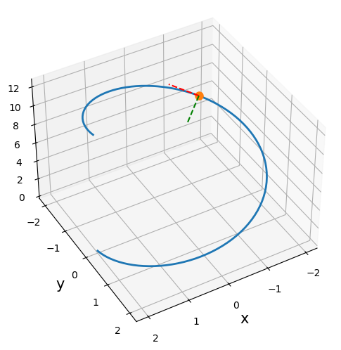

```python
fig = plt.figure(figsize=(10,6))
t = np.linspace(0, 2*np.pi/5,101)
ax = fig.add_subplot(111,projection='3d')
ax.plot(2*np.cos(5*t), 2*np.sin(5*t), 10*t, linewidth=2)
x0 = 2*np.cos(5*np.pi/4)
y0 = 2*np.sin(5*np.pi/4)
z0 = 10*np.pi/4
ax.plot([x0], [y0], [z0], marker='o', markersize=8, linestyle='', )
ax.plot([x0, x0 + 0.5], [y0, y0 - 0.5], [z0, z0 + np.sqrt(2)/2], linestyle='--', color='red' )
ax.plot([x0, x0 + np.sqrt(2)/2], [y0, y0 + np.sqrt(2)/2], [z0, z0], linestyle='--', color='green' )
ax.view_init(azim = 60,elev = 40)
ax.set_xticks(np.arange(-2,3))
ax.set_yticks(np.arange(-2,3))
ax.set_xlabel('x', fontsize=15)
ax.set_ylabel('y', fontsize=15)
ax.set_zlabel('z', fontsize=15)
ax.grid()
```

*2)* Bogenlänge:

$\int_0^T \|\dot{\vec{\mathbf{r}}}\| \mathrm{d}t = \int_0^T \sqrt{1 + 4t^2} \mathrm{d}t = 2\int_0^T \sqrt{\dfrac{1}{4} + t^2} \mathrm{d}t = \left[t\sqrt{\dfrac{1}{4} + t^2} + \dfrac{\ln\left(t + \sqrt{\dfrac{1}{4} + t^2}\right)}{4}\right]_0^T$

$\qquad = T\sqrt{\dfrac{1}{4} + T^2} + \dfrac{\ln\left(T + \sqrt{\dfrac{1}{4} + T^2}\right)}{4} + \dfrac{\ln(4)}{8}$

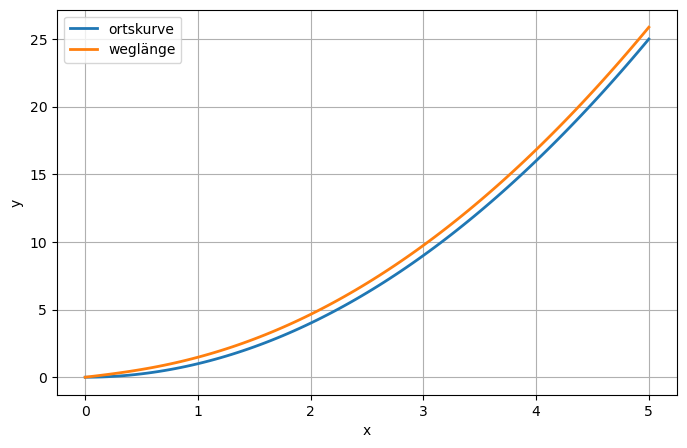

```
Bogenlänge bei t=2: 4.6468
```

```python
T = 2
t = np.linspace(0,5,101)
x = t
y = t**2

s = t*np.sqrt(0.25+t**2) + np.log(t+np.sqrt(t**2+0.25))/4 + np.log(4)/8

fig = plt.figure(figsize=(8,5))
ax1 = fig.add_subplot(111)
ax1.plot(x, y, linewidth=2, label='ortskurve')
ax1.plot(x, s, linewidth=2, label='weglänge')
ax1.set_xlabel('x')
ax1.set_ylabel('y')
ax1.grid()
ax1.legend()
plt.show()

print('Bogenlänge bei t=2: {0:.4f}'.format(2*np.sqrt(0.25+2**2) + np.log(2+np.sqrt(2**2+0.25))/4 + np.log(4)/8 ))
```

*3)*

- Parabel: $\vec{\mathbf{r}}(t) = \left[\begin{array}{c} t \\ t^2 \end{array}\right]$ für $t \ge 0$
- Längenkreis: $\vec{\mathbf{r}}(t) = R\left[\begin{array}{c} \cos(\varphi) \sin(t) \\ \sin(\varphi) \sin(t) \\ \cos(t) \end{array}\right]$ mit $\varphi$ = konstant und $R$ = konstant
- Breitenkreis: $\vec{\mathbf{r}}(t) = R\left[\begin{array}{c} \cos(t) \sin(\vartheta) \\ \sin(t) \sin(\vartheta) \\ \cos(\vartheta) \end{array}\right]$ mit $\vartheta$ = konstant und $R$ = konstant

## Flächen im Raum

1. Gegeben sei der Ortsvektor einer Fläche in Abhängigkeit von den Parametern $u$ und $v$

$$ \vec{\mathbf{r}}(u,v) = \left[\begin{array}{c} u \\ v \\ \sqrt{u^2 + v^2 + 4} \end{array}\right] . $$

Bestimmen Sie für $u=1$ und $v=2$

- den entsprechenden Punkt $P$ auf der Fläche,
- die Tangentenvektoren $\vec{\mathbf{t}}_u$ und $\vec{\mathbf{t}}_v$,
- die Flächennormale $\vec{\mathbf{N}}$,
- und die entsprechende Tangentialebene.
2. Wie lautet die Gleichung der Tangentialebene an die Fläche $z = x^2-y^2$ im Punkt $P = (2,1,3)^{\scriptscriptstyle \mathrm{T}}$
3. Beschreiben Sie folgende Flächen durch parameterabhängige Ortsvektoren:
- die Mantelfläche eines Zylinders mit einer Bodenfläche mit Radius $2$ und einer Höhe von $5$,
- die Oberfläche einer Kugel mit Radius $6$.

#### Lösung

*1)*

- $\vec{\mathbf{r}}(u,v) = \left[\begin{array}{c} 1 \\ 2 \\ \sqrt{1 + 4 + 4} \end{array}\right] = \left[\begin{array}{c} 1 \\ 2 \\ 3 \end{array}\right]$
- $\vec{\mathbf{t}}_u = \left[\begin{array}{c} 1 \\ 0 \\ \frac{u}{\sqrt{u^2 + v^2 + 4}} \end{array}\right] = \left[\begin{array}{c} 1 \\ 0 \\ \frac{1}{3} \end{array}\right], \; \vec{\mathbf{t}}_v = \left[\begin{array}{c} 0 \\ 1 \\ \frac{v}{\sqrt{u^2 + v^2 + 4}} \end{array}\right] = \left[\begin{array}{c} 0 \\ 1 \\ \frac{2}{3} \end{array}\right]$
- $\vec{\mathbf{N}} = \dfrac{\vec{\mathbf{t}}_u \times \vec{\mathbf{t}}_v}{\|\vec{\mathbf{t}}_u \times \vec{\mathbf{t}}_v\|} = \dfrac{1}{\sqrt{2u^2 + 2v^2 + 4}}\left[\begin{array}{c} -u \\ -v \\ \sqrt{u^2 + v^2 + 4} \end{array}\right] = \dfrac{1}{\sqrt{14}}\left[\begin{array}{c} -1 \\ -2 \\ 3 \end{array}\right]$
- $\vec{\mathbf{T}}(\alpha, \beta) = \left[\begin{array}{c} 1 \\ 2 \\ 3 \end{array}\right] + \alpha \left[\begin{array}{c} 1 \\ 0 \\ \frac{1}{3} \end{array}\right] + \beta \left[\begin{array}{c} 0 \\ 1 \\ \frac{2}{3} \end{array}\right]$
- oder $\vec{\mathbf{N}}^{\scriptscriptstyle \mathrm{T}} \left(\vec{\mathbf{r}} - \vec{\mathbf{r}}_0\right) = \dfrac{1}{\sqrt{14}}\left[\begin{array}{c} -1 \\ -2 \\ 3 \end{array}\right]^{\scriptscriptstyle \mathrm{T}} \left(\left[\begin{array}{c} x \\ y \\ z \end{array}\right] - \left[\begin{array}{c} 1 \\ 2 \\ 3 \end{array}\right]\right) = \dfrac{1}{\sqrt{14}} \left(-(x-1) - 2(y-2) + 3(z-3)\right) = 0 \; \rightarrow -x - 2y + 3z = 4$

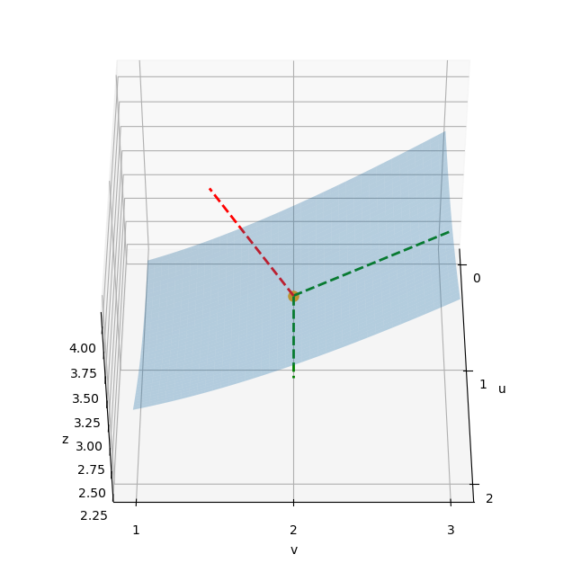

```python
u = np.linspace(0,2,41)
v = np.linspace(1,3,41)
uu,vv = np.meshgrid(u,v)
z = np.sqrt(uu**2 + vv**2 + 4)

fig = plt.figure(figsize=(8,8))
ax = fig.add_subplot(111, projection='3d')
ax.plot_surface(uu,vv,z, alpha=0.3)
ax.plot([1], [2], [3], marker='o', markersize=8, linestyle='', color='orange' )
ax.plot([1,1+1], [2,2], [3,3+1/3], linestyle='--', color='green', linewidth=2 )
ax.plot([1,1], [2,3], [3,3+2/3], linestyle='--', color='green', linewidth=2 )
ax.plot([1,1-1/np.sqrt(14)], [2,2-2/np.sqrt(14)], [3,3+3/np.sqrt(14)],\
        linestyle='--', color='red', linewidth=2 )
ax.set_xticks(np.arange(0,3))
ax.set_yticks(np.arange(1,4))
ax.view_init(45,0)
ax.set_xlabel('u')
ax.set_ylabel('v')
ax.set_zlabel('z')
plt.show()
```

*2)*

- Ortsvektor der Fläche $\vec{\mathbf{r}}(x,y) = \left[\begin{array}{c} x \\ y \\ x^2 - y^2 \end{array}\right] = \left[\begin{array}{c} 2 \\ 1 \\ 4-1 \end{array}\right]$
- Tangentenvektoren: $\vec{\mathbf{t}}_x = \left[\begin{array}{c} 1 \\ 0 \\ 2x \end{array}\right], \; \vec{\mathbf{t}}_y = \left[\begin{array}{c} 0 \\ 1 \\ -2y \end{array}\right]$
- Kreuzprodukt: $\vec{\mathbf{t}}_x \times \vec{\mathbf{t}}_y = \left[\begin{array}{c} -2x \\ 2y \\ 1 \end{array}\right]$
- Tangentialebene im Punkt: $\left[\begin{array}{c} -4 \\ 2 \\ 1 \end{array}\right]^{\scriptscriptstyle \mathrm{T}}\left(\left[\begin{array}{c} x \\ y \\ z \end{array}\right] - \left[\begin{array}{c} 2 \\ 1 \\ 3 \end{array}\right]\right) = -4(x-2) + 2(y-1) + z-3 = 0 \; \rightarrow z = 4x - 2y -3$

*3)*

- $\vec{\mathbf{r}}(u,v) = \left[\begin{array}{c} 2\cos(u) \\ 2\sin(u)\\ v \end{array}\right]$
- $\vec{\mathbf{r}}(u,v) = 6 \left[\begin{array}{c}\cos(u) \sin(v) \\ \sin(u) \sin(v) \\ \cos(v) \end{array}\right]$